# R Notebook

Clustering homework You have been provided some customer data from a shopping centre. Do some exploratory analysis on the data. Comment on findings.

We are interested in creating a marketing campaign to target customers based on their spending score and annual income. Perform a k-means clustering to find if there are meaningful clusters in the data to target the customers.

Perform k-means clustering and chose a value of k.

Visualise the clustering for your chosen value of k.

Do you think the clustering seems a good fit for this data?

Comment on the attributes on one or two of the clusters (maybe even give them a label if you like - like in section 4.1 of the ‘Segmentation & clustering intro’ lesson).

```r
mall_customers <- read_csv("data/mall_customers.csv") %>% clean_names()
```

### Do some exploratory analysis on the data. Comment on findings.

```r
mall_customers %>%
  select(gender) %>%
  group_by(gender) %>%
  summarise(n = n())
```

| gender | n |
| --- | --- |
| Female | 112 |
| Male | 88 |

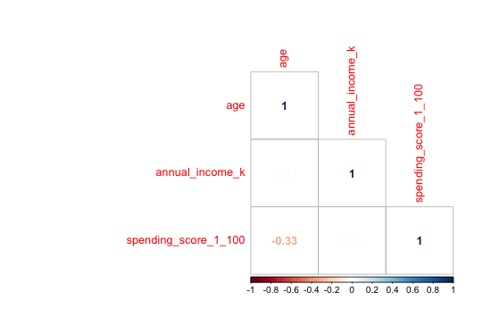

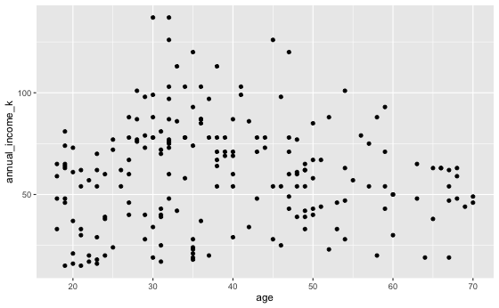

```r
mall_customers %>%
  ggplot() +
  aes(x = age, y = annual_income_k) +
  geom_point()
```

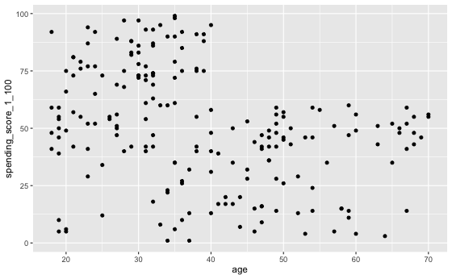

```r
mall_customers %>%
  ggplot() +
  aes(x = age, y = spending_score_1_100) +
  geom_point()
```

### We are interested in creating a marketing campaign to target customers based on their spending score and annual income. Perform a k-means clustering to find if there are meaningful clusters in the data to target the customers.

```r
# tidy the data, k-means clustering method can only work on numeric data
mall_customers <- mall_customers %>%
  column_to_rownames("customer_id") %>%
  select(-c("gender", "age"))

head(mall_customers)
```

|  | annual_income_k | spending_score_1_100 |
| --- | --- | --- |
| 1 | 15 | 39 |
| 2 | 15 | 81 |
| 3 | 16 | 6 |
| 4 | 16 | 77 |
| 5 | 17 | 40 |
| 6 | 17 | 76 |

```r
# standardize data
mall_customers_scale <- mall_customers %>%
  mutate_if(is.numeric, scale)

# check it worked - OK
mall_customers_scale %>%
  as_tibble() %>%
  pivot_longer(cols = c(annual_income_k, spending_score_1_100),
               names_to = "type",
               values_to = "value") %>% #convert data to long format
  group_by(type)%>%
  summarise(mean = round(mean(value)),
            sd = sd(value))
```

| type | mean | sd |
| --- | --- | --- |
| annual_income_k | 0 | 1 |
| spending_score_1_100 | 0 | 1 |

Choosing the number of clusters:

#### 3. Gap